# Task 8

Bowen Tan

2026-10-28

### Install and load packages

```r
#devtools::install_github("hirscheylab/tidybiology")
library(tidybiology)
library(tidyverse)
library(patchwork)

data("chromosome")
data("proteins")
```

## a. Extract summary statistics (mean, median and maximum) for the following variables from the ‘chromosome’ data: variations, protein coding genes, and miRNAs.

```r
chromosome %>%
  summarise(
    across(
      c(variations, protein_codinggenes, mi_rna),
      list(
        mean = ~mean(.x, na.rm = TRUE),
        median = ~median(.x, na.rm = TRUE),
        max = ~max(.x, na.rm = TRUE)
      )
    )
  )
```

```
## # A tibble: 1 × 9
##   variations_mean variations_median variations_max protein_codinggenes_mean
##             <dbl>             <dbl>          <dbl>                    <dbl>
## 1        6484572.           6172346       12945965                     850.
## # ℹ 5 more variables: protein_codinggenes_median <dbl>,
## #   protein_codinggenes_max <int>, mi_rna_mean <dbl>, mi_rna_median <dbl>,
## #   mi_rna_max <int>
```

## b. How does the chromosome size distribute? Plot a graph that helps to visualize this by using ggplot2 package functions.

```r
summary(chromosome$length_mm)
```

```
##    Min. 1st Qu.  Median    Mean 3rd Qu.    Max.
##   16.00   27.75   45.50   43.83   55.00   85.00
```

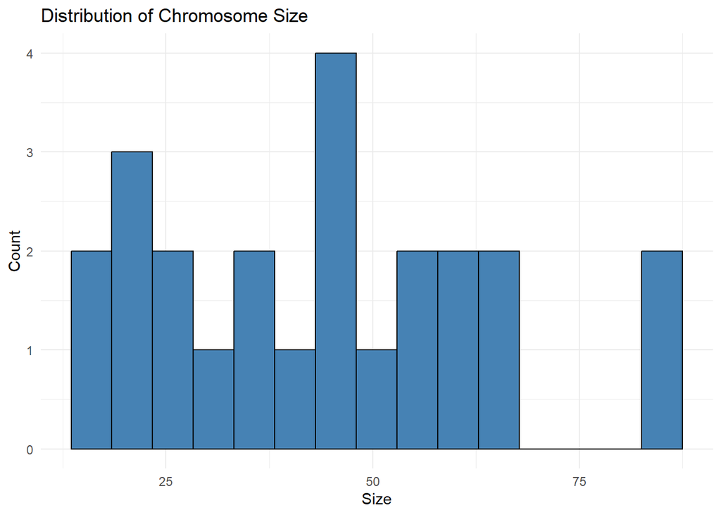

```r
ggplot(chromosome, aes(x = length_mm)) +
  geom_histogram(bins = 15, fill = "steelblue", color = "black") +
  labs(
    title = "Distribution of Chromosome Size",
    x = "Size",
    y = "Count"
  ) +
  theme_minimal()
```

The chromosome +size is from 16 to 85, with mean 43.83 and median 45.50. As shown in the histogram, most chromosomes have sizes between approximately 15 and 65, with a concentration around 40 and 50.

## c. Does the number of protein coding genes or miRNAs correlate with the length of the chromosome? Make two separate plots to visualize these relationships.

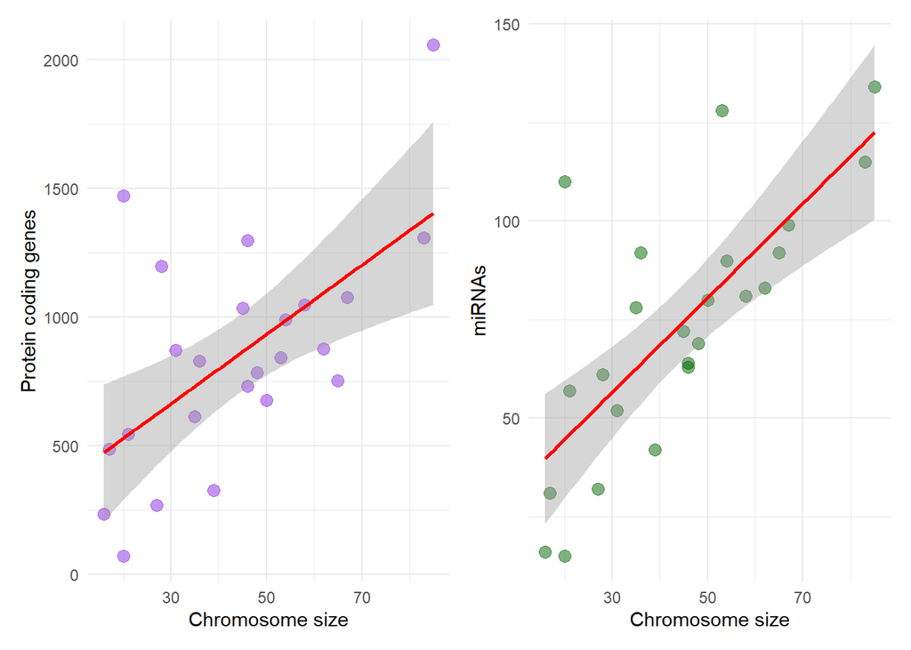

```r
p1 <- ggplot(chromosome, aes(y= protein_codinggenes, x= length_mm)) +
  geom_point(alpha=0.50, size=3, color = "blueviolet") +
  geom_smooth(method=lm, color = "red") +
  labs(x="Chromosome size", y = "Protein coding genes") +
  theme_minimal()

p2 <- ggplot(chromosome, aes(y= mi_rna, x= length_mm)) +
  geom_point(alpha=0.50, size=3, color = "darkgreen") +
  geom_smooth(method=lm, color = "red") +
  labs(x="Chromosome size", y = "miRNAs") +
  theme_minimal()

p1 + p2
```

Plots show that both the number of protein coding genes and miRNAs increase when the length of the chromosome increase.

## d. Calculate the same summary statistics for the ‘proteins’ data variables length and mass. Create a meaningful visualization of the relationship between these two variables by utilizing the ggplot2 package functions. Play with the colors, theme- and other visualization parameters to create a plot that pleases you.

```r
# Summary statistics
proteins %>%
  summarise(
    across(
      c(length, mass),
      list(
        mean = ~mean(.x, na.rm = TRUE),
        median = ~median(.x, na.rm = TRUE),
        max = ~max(.x, na.rm = TRUE)
      )
    )
  )
```

```
## # A tibble: 1 × 6
##   length_mean length_median length_max mass_mean mass_median mass_max
##         <dbl>         <dbl>      <dbl>     <dbl>       <dbl>    <dbl>
## 1        557.           414      34350    62061.      46140.  3816030
```

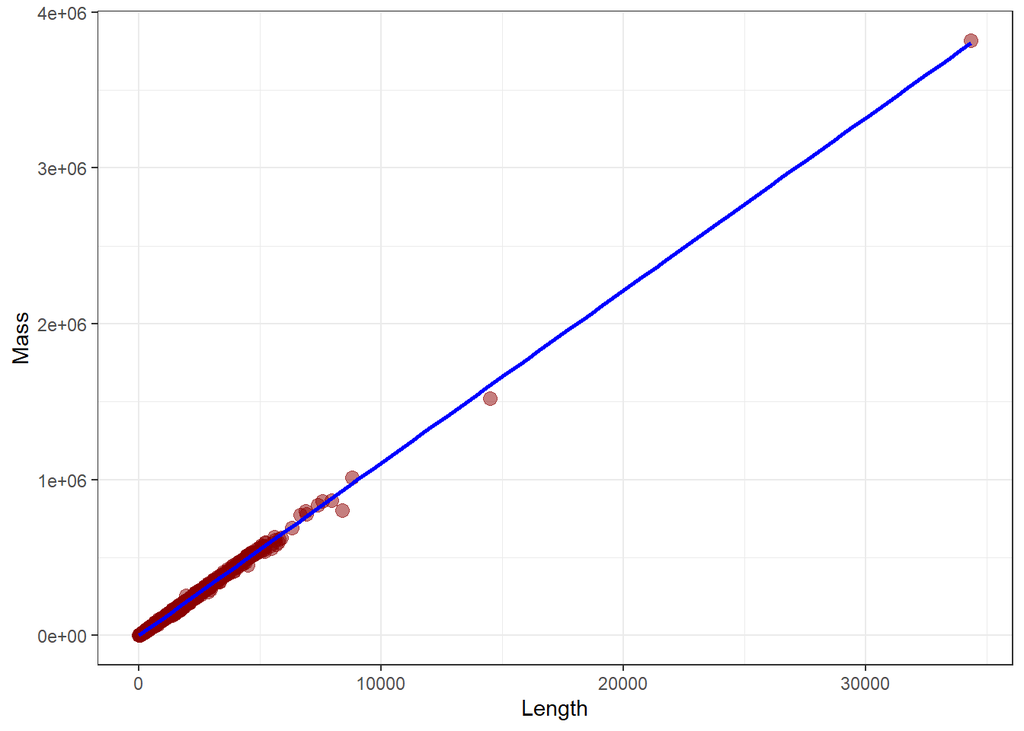

```r
# Plot
ggplot(proteins, aes(y= mass, x= length)) +
  geom_point(alpha=0.50, size=3, color = "darkred") +
  geom_smooth(method=lm, color = "blue") +
  labs(x="Length", y = "Mass") +
  theme_bw()
```

Length and mass show strong positive linear correlation.